# Install Anaconda & Start Coding in Jupyter Notebook

## 🔧 Step 1: Download and Install Anaconda

- Visit: https://www.anaconda.com/products/distribution
- Choose your operating system (Windows, macOS, Linux).
- Download the 64-bit Graphical Installer.
- Run the installer and follow the prompts (default settings are fine).

## 🔧 Step 2: Launch Jupyter Notebook

- Open Anaconda Navigator.
- Click Launch under Jupyter Notebook.
- A browser window will open showing the Jupyter interface.
- Click New > Python 3 to start a new notebook.

## 🔧 Step 3: Install NumPy, pandas, and Matplotlib

These libraries may already be included with Anaconda, but to ensure they’re up to date:

Option A: Using Jupyter Notebook In a notebook cell, run:

```python
# !pip install numpy pandas matplotlib
```

Option B: Using Anaconda Prompt or Terminal Open Anaconda Prompt (Windows) or Terminal (macOS/Linux), then run:

```python
# pip install numpy pandas matplotlib
```

Or, if you prefer using conda:

```python
# conda install numpy pandas matplotlib
```

## 🔧 Step 4: Import Required Libraries

We begin by importing the essential libraries for numerical computation, data manipulation, and plotting.

```python
import numpy as np
import pandas as pd
import matplotlib.pyplot as plt
```

## 🔧 Step 5: Create a Simple Dataset

We'll create a small dataset representing values over a few years.

```python
data = pd.DataFrame({
    'Year': [2018, 2019, 2020, 2021, 2022],
    'Value': [100, 120, 130, 160, 180]
})

# Display the dataset
data
```

|  | Year | Value |
| --- | --- | --- |
| 0 | 2018 | 100 |
| 1 | 2019 | 120 |
| 2 | 2020 | 130 |
| 3 | 2021 | 160 |
| 4 | 2022 | 180 |

## 📈 Step 6: Plot the Data

Now we visualize the data using a line plot.

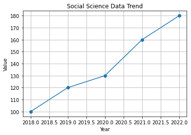

```python
plt.plot(data['Year'], data['Value'], marker='o')
plt.title('Social Science Data Trend')
plt.xlabel('Year')
plt.ylabel('Value')
plt.grid(True)
plt.show()
```

## ✅ Summary

You've learned how to:

- Import libraries
- Create a dataset using pandas
- Visualize data using Matplotlib

You can now explore more datasets and apply statistical analysis techniques!